# 8 - Data Exploration

Joseph Rickert

Wednesday, August 27, 2014

In this section we will show off some R features for exploring data using plots from various contributed packages.

```r
library(Hmisc)                            # for describe()
library(fBasics)
```

```r
library(gplots)                       # for barplot
library(ggplot2)                      # for boxplots
library(ellipse)                          # for correlation plot
library(rattle)                       # for the weather data set
```

## The Weather Data

We will use the weather data set that is included in the rattle package. First we fetch the data from the package and then write it to disk in the working directory. After that, we can read the data directly from disk.

```r
data(weather)  # load in the weather data set from the rattle package
# Write the weather data set to disk
name <- "weather.csv"                 # name the the disk file
dataDir <- getwd()                    # Set the directory
file <- file.path(dataDir,name)        # Construct the file path
write.table(weather,file,row.names=FALSE,sep=",")  # write to disk
# weather <- read.table(file,header=TRUE,sep=",")  # read the data from disk
# weather <- read.csv(file)           # read.csv is a wrapper function for write table
#
head(weather)                         # Look at the data
```

```
##         Date Location MinTemp MaxTemp Rainfall Evaporation Sunshine
## 1 2007-11-01 Canberra     8.0    24.3      0.0         3.4      6.3
## 2 2007-11-02 Canberra    14.0    26.9      3.6         4.4      9.7
## 3 2007-11-03 Canberra    13.7    23.4      3.6         5.8      3.3
## 4 2007-11-04 Canberra    13.3    15.5     39.8         7.2      9.1
## 5 2007-11-05 Canberra     7.6    16.1      2.8         5.6     10.6
## 6 2007-11-06 Canberra     6.2    16.9      0.0         5.8      8.2
##   WindGustDir WindGustSpeed WindDir9am WindDir3pm WindSpeed9am
## 1          NW            30         SW         NW            6
## 2         ENE            39          E          W            4
## 3          NW            85          N        NNE            6
## 4          NW            54        WNW          W           30
## 5         SSE            50        SSE        ESE           20
## 6          SE            44         SE          E           20
##   WindSpeed3pm Humidity9am Humidity3pm Pressure9am Pressure3pm Cloud9am
## 1           20          68          29        1020        1015        7
## 2           17          80          36        1012        1008        5
## 3            6          82          69        1010        1007        8
## 4           24          62          56        1006        1007        2
## 5           28          68          49        1018        1018        7
## 6           24          70          57        1024        1022        7
##   Cloud3pm Temp9am Temp3pm RainToday RISK_MM RainTomorrow
## 1        7    14.4    23.6        No     3.6          Yes
## 2        3    17.5    25.7       Yes     3.6          Yes
## 3        7    15.4    20.2       Yes    39.8          Yes
## 4        7    13.5    14.1       Yes     2.8          Yes
## 5        7    11.1    15.4       Yes     0.0           No
## 6        5    10.9    14.8        No     0.2           No
```

```r
weather <- weather[,-c(1,2)]          # Drop the first two columns
```

## Numerical Summaries

We will begin by getting numerical summaries for some variables

```r
summary(weather)                      # Get a summary
```

```
##     MinTemp         MaxTemp        Rainfall      Evaporation
##  Min.   :-5.30   Min.   : 7.6   Min.   : 0.00   Min.   : 0.20
##  1st Qu.: 2.30   1st Qu.:15.0   1st Qu.: 0.00   1st Qu.: 2.20
##  Median : 7.45   Median :19.6   Median : 0.00   Median : 4.20
##  Mean   : 7.27   Mean   :20.6   Mean   : 1.43   Mean   : 4.52
##  3rd Qu.:12.50   3rd Qu.:25.5   3rd Qu.: 0.20   3rd Qu.: 6.40
##  Max.   :20.90   Max.   :35.8   Max.   :39.80   Max.   :13.80
##
##     Sunshine      WindGustDir  WindGustSpeed    WindDir9am    WindDir3pm
##  Min.   : 0.00   NW     : 73   Min.   :13.0   SE     : 47   WNW    : 61
##  1st Qu.: 5.95   NNW    : 44   1st Qu.:31.0   SSE    : 40   NW     : 61
##  Median : 8.60   E      : 37   Median :39.0   NNW    : 36   NNW    : 47
##  Mean   : 7.91   WNW    : 35   Mean   :39.8   N      : 31   N      : 30
##  3rd Qu.:10.50   ENE    : 30   3rd Qu.:46.0   NW     : 30   ESE    : 27
##  Max.   :13.60   (Other):144   Max.   :98.0   (Other):151   (Other):139
##  NA's   :3       NA's   :  3   NA's   :2      NA's   : 31   NA's   :  1
##   WindSpeed9am    WindSpeed3pm  Humidity9am  Humidity3pm    Pressure9am
##  Min.   : 0.00   Min.   : 0    Min.   :36   Min.   :13.0   Min.   : 996
##  1st Qu.: 6.00   1st Qu.:11    1st Qu.:64   1st Qu.:32.2   1st Qu.:1015
##  Median : 7.00   Median :17    Median :72   Median :43.0   Median :1020
##  Mean   : 9.65   Mean   :18    Mean   :72   Mean   :44.5   Mean   :1020
##  3rd Qu.:13.00   3rd Qu.:24    3rd Qu.:81   3rd Qu.:55.0   3rd Qu.:1024
##  Max.   :41.00   Max.   :52    Max.   :99   Max.   :96.0   Max.   :1036
##  NA's   :7
##   Pressure3pm      Cloud9am       Cloud3pm       Temp9am
##  Min.   : 997   Min.   :0.00   Min.   :0.00   Min.   : 0.10
##  1st Qu.:1013   1st Qu.:1.00   1st Qu.:1.00   1st Qu.: 7.62
##  Median :1017   Median :3.50   Median :4.00   Median :12.55
##  Mean   :1017   Mean   :3.89   Mean   :4.03   Mean   :12.36
##  3rd Qu.:1022   3rd Qu.:7.00   3rd Qu.:7.00   3rd Qu.:17.00
##  Max.   :1033   Max.   :8.00   Max.   :8.00   Max.   :24.70
##
##     Temp3pm     RainToday    RISK_MM      RainTomorrow
##  Min.   : 5.1   No :300   Min.   : 0.00   No :300
##  1st Qu.:14.2   Yes: 66   1st Qu.: 0.00   Yes: 66
##  Median :18.6             Median : 0.00
##  Mean   :19.2             Mean   : 1.43
##  3rd Qu.:24.0             3rd Qu.: 0.20
##  Max.   :34.5             Max.   :39.80
##
```

```r
describe(weather)                     # Get another summary
```

```
## weather
##
##  22  Variables      366  Observations
## ---------------------------------------------------------------------------
## MinTemp
##       n missing  unique    Mean     .05     .10     .25     .50     .75
##     366       0     180   7.266  -2.075  -0.900   2.300   7.450  12.500
##     .90     .95
##  15.300  16.500
##
## lowest : -5.3 -3.7 -3.5 -3.4 -3.3, highest: 17.9 18.0 18.2 19.9 20.9
## ---------------------------------------------------------------------------
## MaxTemp
##       n missing  unique    Mean     .05     .10     .25     .50     .75
##     366       0     187   20.55   11.12   12.15   15.03   19.65   25.50
##     .90     .95
##   29.95   33.20
##
## lowest :  7.6  8.4  8.7  8.8  9.3, highest: 34.9 35.0 35.2 35.7 35.8
## ---------------------------------------------------------------------------
## Rainfall
##       n missing  unique    Mean     .05     .10     .25     .50     .75
##     366       0      47   1.428     0.0     0.0     0.0     0.0     0.2
##     .90     .95
##     4.3     8.8
##
## lowest :  0.0  0.2  0.4  0.6  0.8, highest: 19.2 19.8 22.6 25.8 39.8
## ---------------------------------------------------------------------------
## Evaporation
##       n missing  unique    Mean     .05     .10     .25     .50     .75
##     366       0      55   4.522     1.2     1.5     2.2     4.2     6.4
##     .90     .95
##     8.4     9.4
##
## lowest :  0.2  0.6  0.8  1.0  1.2, highest: 11.4 11.6 12.4 12.6 13.8
## ---------------------------------------------------------------------------
## Sunshine
##       n missing  unique    Mean     .05     .10     .25     .50     .75
##     363       3     114   7.909    0.60    2.04    5.95    8.60   10.50
##     .90     .95
```

[output cut: 123 more lines]

```
## ---------------------------------------------------------------------------
## RISK_MM
##       n missing  unique    Mean     .05     .10     .25     .50     .75
##     366       0      47   1.428     0.0     0.0     0.0     0.0     0.2
##     .90     .95
##     4.3     8.8
##
## lowest :  0.0  0.2  0.4  0.6  0.8, highest: 19.2 19.8 22.6 25.8 39.8
## ---------------------------------------------------------------------------
## RainTomorrow
##       n missing  unique
##     366       0       2
##
## No (300, 82%), Yes (66, 18%)
## ---------------------------------------------------------------------------
```

```r
#
nm <- names(weather)
ind <- which(nm=="Sunshine"|nm=="WindGustSpeed"|nm=="WindSpeed9am"|nm=="WindSpeed3pm")
skewness(weather[,ind],na.rm=TRUE)  # > 1 means big skew
```

```
##      Sunshine WindGustSpeed  WindSpeed9am  WindSpeed3pm
##       -0.7235        0.8361        1.3602        0.5913
```

```r
kurtosis(weather[,ind],na.rm=TRUE)  # > 1 means spikey peak
```

```
##      Sunshine WindGustSpeed  WindSpeed9am  WindSpeed3pm
##       -0.2706        1.4761        1.4758        0.1963
```

## Bar Plot

We are eventually going to look at some machine learning algorithms with this data set. Our “target” variable for predictions will be the binary variable, RainTomorrow. So let’s produce a bar plot to have a look at it. The ‘gplots’ package provides the ‘barplot2’ function. First, we generate the summary data for plotting.

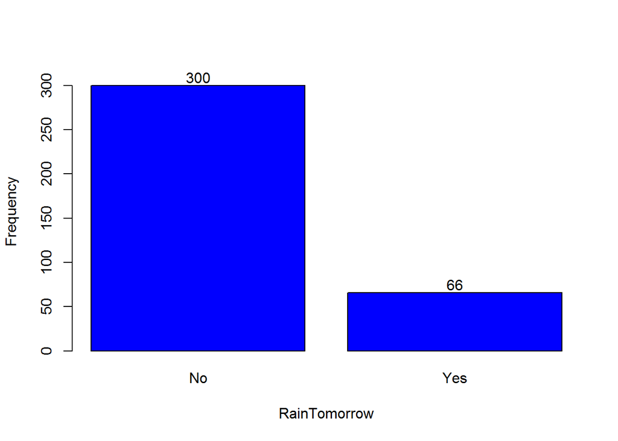

```r
ds <- summary(na.omit(weather$RainTomorrow))
# Plot the data.
bp <-  barplot2(ds, beside=TRUE, ylab="Frequency", xlab="RainTomorrow", ylim=c(0, max(ds)+15), col="blue")
text(bp, ds+9, ds)                                    # Add the actual frequencies to the plot
```

## Histograms We will build a little function to generate a custom histogram

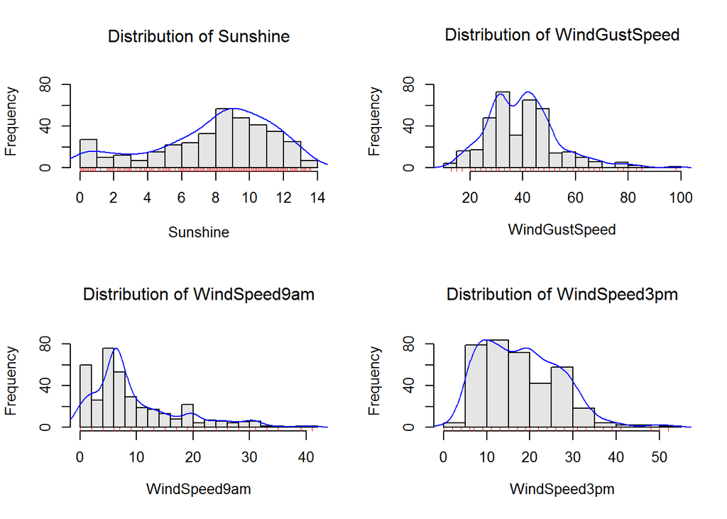

```r
attach(weather)                                                  # make the columns of weather available in the global environment
jhist <- function(var){
            hs <- hist(var,                                             # plot histogram
                  main=substitute(paste("Distribution of ",var)),  # title with variable name
                  xlab=substitute(var),                             # x-axis label with variable name
                    ylab="Frequency",                                     # y-axis title
            col="grey90",                                           # color of histogram
                    ylim=c(0, 90),                                        # limits of histogram
                    breaks="fd",                                              # use the Freedman-Diaconis algorithm for breakpoints
                    border=TRUE)                                              # set border
                dens <- density(var, na.rm=TRUE)            # kernel density estimation
                rs <- max(hs$counts)/max(dens$y)            # compute scale factor for density
                lines(dens$x, dens$y*rs,                            # plot density curve
                  type="l",                                                   # plot density as a solid line
                  col="blue")                                           # set the colors
                rug(var,col="red")                                      # Add a rug to the plot
}

par(mfrow=c(2,2))                                               # Put 4 plots on the same graph
jhist(Sunshine)
jhist(WindGustSpeed)
jhist(WindSpeed9am)
jhist(WindSpeed3pm)
```

```r
detach(weather)                                 # remove weather variables from environment
```

Next, we will xonstructa Panel Histogram to look at pairwise correlations. The code for this example comes from page 124 of the book: Data Mining with R and Rattle http://amzn.to/1qzExMc

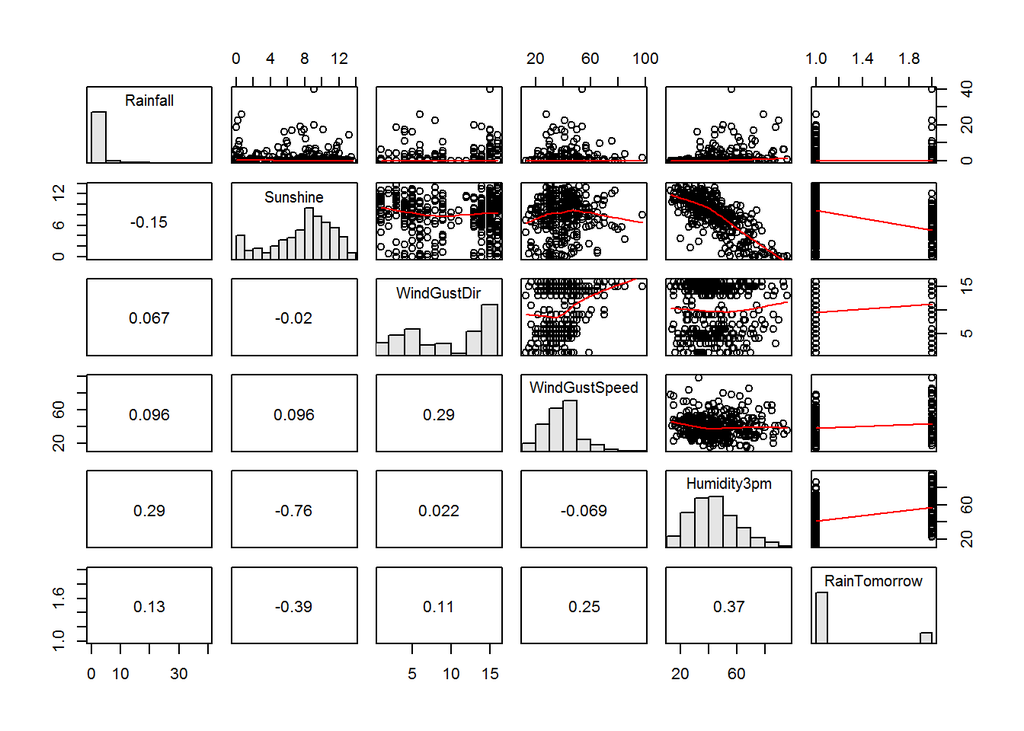

```r
panel.hist <- function(x,...)
{
    usr <- par("usr"); on.exit(par(usr))
    par(usr=c(usr[1:2],0,1.5))
    h <- hist(x,plot=FALSE)
    breaks <-h$breaks; nB <- length(breaks)
    y <- h$counts; y <- y/max(y)
    rect(breaks[-nB],0,breaks[-1],y, col="grey90",...)
}

panel.cor <- function(x,y,digits=2,prefix="",cex.cor,...)
{
    usr <- par("usr"); on.exit(par(usr))
    par(usr = c(0,1,0,1))
    r <- cor(x,y,use="complete")
    txt <- format(c(r,0.123456789),digits=digits)[1]
    txt <- paste(prefix,txt,sep="")
    if(missing(cex.cor)) cex.cor <- 0.8/strwidth(txt)
    text(0.5,0.5,txt)
}
# Pick out the variables to put in the panels
nm <- names(weather)
vars <- which(nm=="Rainfall"|nm=="Sunshine"|nm=="WindGustDir"|
                nm=="WindGustSpeed"|nm=="Humidity3pm"|nm=="RainTomorrow")
# Plot
pairs(weather[,vars],diag.panel=panel.hist,upper.panel=panel.smooth,lower.panel=panel.cor)
```

## Boxplots Let’s have a look at the distribution of wind spped by direction.

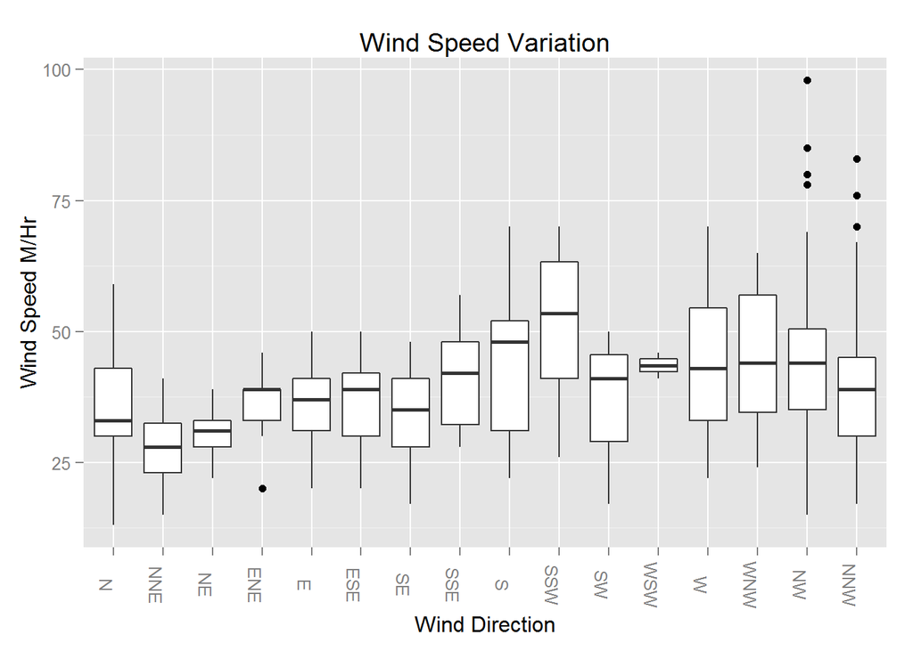

```r
df <- na.omit(weather)              # build a data frame for plotting without NAs
b <- ggplot(df,aes(factor(WindGustDir),WindGustSpeed))
b + geom_boxplot() +
     xlab("Wind Direction") +
   theme(axis.text.x=element_text(angle=-90))+
     ylab("Wind Speed M/Hr") +
     ggtitle("Wind Speed Variation")
```

## Correlations The ‘ellipse’ package provides the ‘plotcorr’ function. Correlations work for numeric variables only.

```r
# to get bick out the numeric variables from weather you can type the names in by hand
# numeric <- c("MinTemp", "MaxTemp", "Rainfall", "Evaporation",
#               "Sunshine", "WindGustSpeed", "WindSpeed9am", "WindSpeed3pm",
#               "Humidity9am", "Humidity3pm", "Pressure9am", "Pressure3pm",
#               "Cloud9am", "Cloud3pm", "Temp9am", "Temp3pm")
#
# or try something like this:
nvars <- names(weather[,sapply(weather,is.numeric)==TRUE])   # Can you unpack this?
nvars <- nvars[-17]
corr <- cor(weather[,nvars], use="pairwise", method="pearson")
ord <- order(corr[1,])            # Order the correlations by their strength.
corr <- corr[ord, ord]
print(corr)
```

```
##               Pressure9am Pressure3pm Humidity9am WindSpeed3pm Humidity3pm
## Pressure9am      1.000000     0.96789      0.1357    -0.359800    -0.08795
## Pressure3pm      0.967895     1.00000      0.1344    -0.337325    -0.01005
## Humidity9am      0.135727     0.13442      1.0000    -0.266092     0.54672
## WindSpeed3pm    -0.359800    -0.33733     -0.2661     1.000000    -0.02637
## Humidity3pm     -0.087946    -0.01005      0.5467    -0.026368     1.00000
## Sunshine         0.006276    -0.03620     -0.4990     0.072573    -0.75943
## Cloud3pm        -0.141000    -0.14384      0.2719     0.007207     0.51011
## WindSpeed9am    -0.356332    -0.24795     -0.2706     0.472966     0.14666
## Rainfall        -0.331581    -0.25022      0.1501     0.056008     0.28901
## Cloud9am        -0.157553    -0.12894      0.3928    -0.026426     0.55163
## WindGustSpeed   -0.540180    -0.52689     -0.3498     0.693945    -0.06944
## Evaporation     -0.381906    -0.39109     -0.5196     0.048601    -0.39178
## Temp3pm         -0.253674    -0.34549     -0.3551    -0.187570    -0.58168
## MaxTemp         -0.290883    -0.37939     -0.3596    -0.167873    -0.53333
## Temp9am         -0.460418    -0.49264     -0.4366    -0.017766    -0.25568
## MinTemp         -0.501707    -0.49801     -0.2079    -0.065922    -0.04071
##                Sunshine  Cloud3pm WindSpeed9am  Rainfall Cloud9am
## Pressure9am    0.006276 -0.141000     -0.35633 -0.331581 -0.15755
## Pressure3pm   -0.036201 -0.143837     -0.24795 -0.250218 -0.12894
## Humidity9am   -0.499017  0.271938     -0.27062  0.150109  0.39284
## WindSpeed3pm   0.072573  0.007207      0.47297  0.056008 -0.02643
## Humidity3pm   -0.759429  0.510108      0.14666  0.289013  0.55163
## Sunshine       1.000000 -0.661131     -0.06452 -0.150990 -0.68109
## Cloud3pm      -0.661131  1.000000     -0.02247  0.127792  0.52522
## WindSpeed9am  -0.064522 -0.022471      1.00000  0.219637  0.10184
## Rainfall      -0.150990  0.127792      0.21964  1.000000  0.18005
## Cloud9am      -0.681092  0.525218      0.10184  0.180046  1.00000
## WindGustSpeed  0.095843  0.050230      0.52765  0.096190 -0.01267
## Evaporation    0.318025 -0.100045      0.06893 -0.007293 -0.10601
## Temp3pm        0.470447 -0.172814     -0.23519 -0.087493 -0.20234
## MaxTemp        0.452064 -0.135991     -0.21681 -0.073560 -0.17573
## Temp9am        0.219509  0.040945      0.06407  0.077299  0.02104
## MinTemp        0.035711  0.118397      0.12754  0.201939  0.21578
##               WindGustSpeed Evaporation  Temp3pm  MaxTemp  Temp9am
## Pressure9am        -0.54018   -0.381906 -0.25367 -0.29088 -0.46042
## Pressure3pm        -0.52689   -0.391093 -0.34549 -0.37939 -0.49264
## Humidity9am        -0.34979   -0.519587 -0.35512 -0.35960 -0.43655
## WindSpeed3pm        0.69394    0.048601 -0.18757 -0.16787 -0.01777
## Humidity3pm        -0.06944   -0.391780 -0.58168 -0.53333 -0.25568
```

[output cut: 13 more lines]

```
## Pressure3pm   -0.49801
## Humidity9am   -0.20790
## WindSpeed3pm  -0.06592
## Humidity3pm   -0.04071
## Sunshine       0.03571
## Cloud3pm       0.11840
## WindSpeed9am   0.12754
## Rainfall       0.20194
## Cloud9am       0.21578
## WindGustSpeed  0.21802
## Evaporation    0.64993
## Temp3pm        0.72273
## MaxTemp        0.75247
## Temp9am        0.91675
## MinTemp        1.00000
```

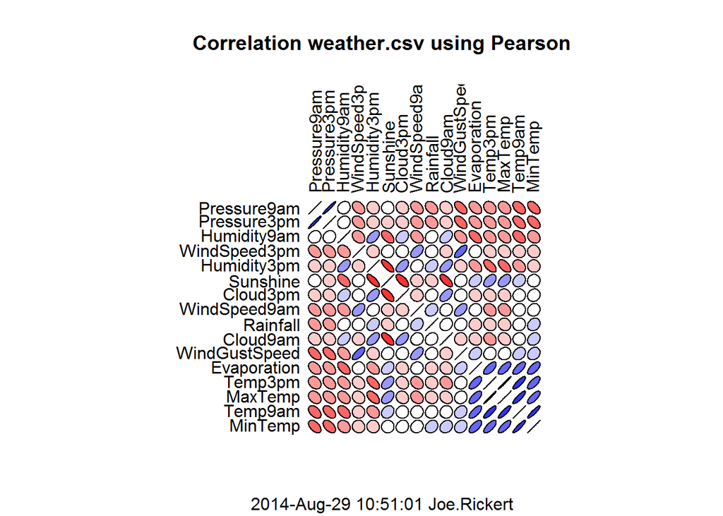

```r
par(mfrow=c(1,1))
plotcorr(corr, col=colorRampPalette(c("red", "white", "blue"))(11)[5*corr + 6])
    title(main="Correlation weather.csv using Pearson",
    sub=paste(format(Sys.time(), "%Y-%b-%d %H:%M:%S"), Sys.info()["user"]))
```

Finally, we will look at correlations among missing values. na.omit removes rows contianing NAs, The row numbers of the cases form the “na.action” attribute of the result, of class “omit”. So na.rows below contains the row numbers of the missing data points

```r
na.rows <- attr(na.omit(t(weather)), "na.action")
corr <- cor(is.na(weather[na.rows]), use="pairwise", method="pearson")
ord <- order(corr[1,])            # Order the correlations by their strength.
corr <- corr[ord,ord]
print(corr)
```

```
##               WindGustDir  Sunshine WindGustSpeed WindDir3pm WindSpeed9am
## WindGustDir      1.000000 -0.008264      0.815374  -0.004758    -0.012694
## Sunshine        -0.008264  1.000000     -0.006739  -0.004758    -0.012694
## WindGustSpeed    0.815374 -0.006739      1.000000  -0.003880    -0.010351
## WindDir3pm      -0.004758 -0.004758     -0.003880   1.000000    -0.007309
## WindSpeed9am    -0.012694 -0.012694     -0.010351  -0.007309     1.000000
## WindDir9am      -0.027654 -0.027654     -0.022549  -0.015923     0.459032
##               WindDir9am
## WindGustDir     -0.02765
## Sunshine        -0.02765
## WindGustSpeed   -0.02255
## WindDir3pm      -0.01592
## WindSpeed9am     0.45903
## WindDir9am       1.00000
```

```r
cat('\nCount of missing values:\n')
```

```
##
## Count of missing values:
```

```r
print(apply(is.na(weather[na.rows]),2,sum))
```

```
##    WindDir9am  WindSpeed9am   WindGustDir WindGustSpeed      Sunshine
##            31             7             3             2             3
##    WindDir3pm
##             1
```

```r
cat('\nPercent missing values:\n')
```

```
##
## Percent missing values:
```

```r
print(100*apply(is.na(weather[na.rows]), 2,sum)/nrow(weather))
```

```
##    WindDir9am  WindSpeed9am   WindGustDir WindGustSpeed      Sunshine
##        8.4699        1.9126        0.8197        0.5464        0.8197
##    WindDir3pm
##        0.2732
```

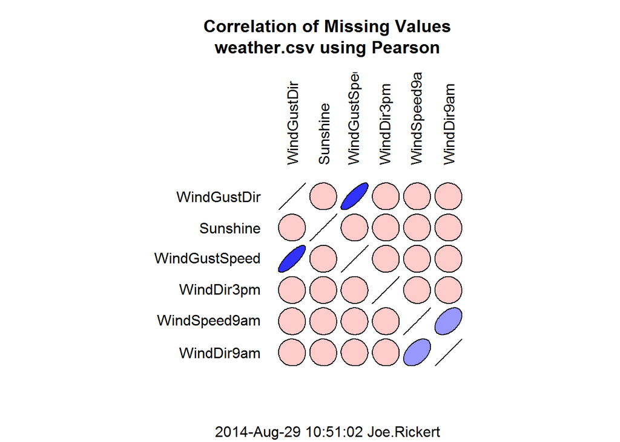

```r
#
plotcorr(corr, col=colorRampPalette(c("red", "white", "blue"))(11)[5*corr + 6])
title(main="Correlation of Missing Values\nweather.csv using Pearson",
    sub=paste(format(Sys.time(), "%Y-%b-%d %H:%M:%S"), Sys.info()["user"]))
```